# Task2

Rachel Smith

3/16/2021

### Tasks to accomplish

- Exploratory analysis - perform a thorough exploratory analysis of the data, understanding the distribution of words and relationship between the words in the corpora.
- Understand frequencies of words and word pairs - build figures and tables to understand variation in the frequencies of words and word pairs in the data.

### Questions to consider

- Some words are more frequent than others - what are the distributions of word frequencies?
- What are the frequencies of 2-grams and 3-grams in the dataset?
- How many unique words do you need in a frequency sorted dictionary to cover 50% of all word instances in the language? 90%?
- How do you evaluate how many of the words come from foreign languages?
- Can you think of a way to increase the coverage – identifying words that may not be in the corpora or using a smaller number of words in the dictionary to cover the same number of phrases?

### Read in and format data

```r
str_eng_news <- readLines("data/final/en_US/en_US.news.txt")
str_eng_blogs <- readLines("data/final/en_US/en_US.blogs.txt")
str_eng_twitter <- readLines("data/final/en_US/en_US.twitter.txt")
```

```r
# convert each to tibble
df_eng_news <- tibble(line = 1:length(str_eng_news), text = str_eng_news)
df_eng_blogs <- tibble(line = 1:length(str_eng_blogs), text = str_eng_blogs)
df_eng_twitter <- tibble(line = 1:length(str_eng_twitter), text = str_eng_twitter)

# unnest tokens
df_eng_news_unnest <- df_eng_news %>%
       unnest_tokens(word, text) %>% # makes lowercase
       mutate(source = "news")

df_eng_blogs_unnest <- df_eng_blogs %>%
       unnest_tokens(word, text) %>%
       mutate(source = "blogs")

df_eng_twitter_unnest <- df_eng_twitter %>%
       unnest_tokens(word, text) %>%
       mutate(source = "twitter")

# remove numbers since we're looking at words
df_eng_news_unnest <- df_eng_news_unnest %>% filter(!grepl("[0-9]", word))
df_eng_blogs_unnest <- df_eng_blogs_unnest %>% filter(!grepl("[0-9]", word))
df_eng_twitter_unnest <- df_eng_twitter_unnest %>% filter(!grepl("[0-9]", word))

# combine into one
df_eng <- rbind(df_eng_news_unnest, df_eng_blogs_unnest, df_eng_twitter_unnest)

# remove stop words
df_eng <- df_eng %>% anti_join(stop_words, by = "word")
```

### Determine most common single words across all sources

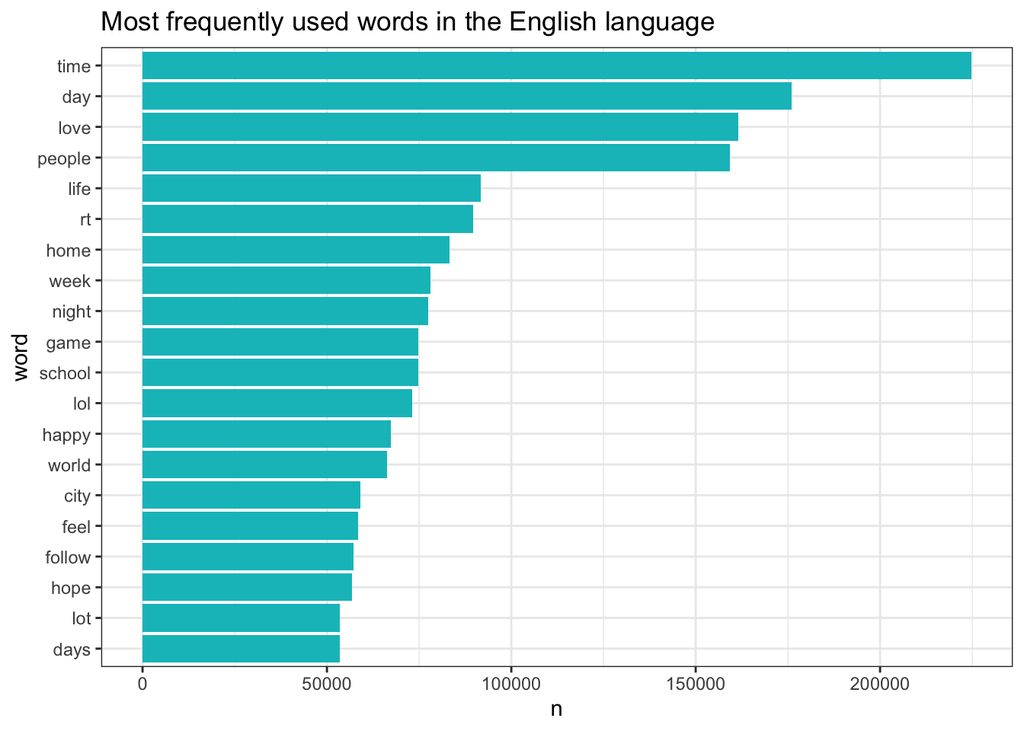

```r
# distribution of words
df_eng_wordcount <- df_eng %>% count(word, sort = TRUE)

df_eng_wordcount %>% head(n = 20) %>% mutate(word = reorder(word, n)) %>%

       ggplot(aes(x = n, y = word)) +
       geom_col(fill = "#00BFC4") +
       theme_bw() +
       ggtitle("Most frequently used words in the English language")
```

Note: removed stop words for the purpose of looking at interesting word freqs, but will want to include these in the text predictor.

#### Wordcloud

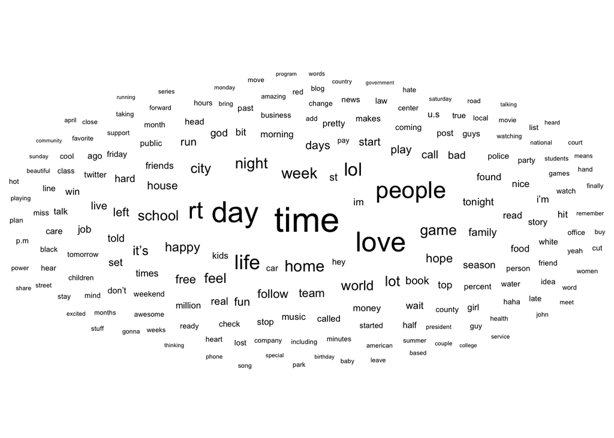

```r
ggplot(df_eng_wordcount %>% head(n = 200), aes(label = word, size = n)) +
               geom_text_wordcloud_area(rm_outside = TRUE) +
               scale_size_area(max_size = 10) +
               theme_minimal()
```

### Sentiment analysis

Get a feel for the sentiments being expressed by people in the news, on blogs, and on twitter, using three different sentiment analysis databases.

```r
df_afinn <- get_sentiments("afinn")
df_bing <- get_sentiments("bing")
df_nrc <- get_sentiments("nrc")
```

Overall (all sources combined)

[figure not shown]

[figure not shown]

[figure not shown]

```r
# AFINN
df_eng %>%
       inner_join(df_afinn, by = "word") %>%
       count(value, sort = TRUE) %>%
       mutate(value = reorder(value, n)) %>%

       ggplot(aes(x = n, y = as.factor(value))) +
       geom_col(fill = "#00BFC4") +
       ylab("value") +
       theme_bw() +
       ggtitle("Frequency of AFINN sentiments in English language")

# Bing et al.
df_eng %>%
       inner_join(df_bing, by = "word") %>%
       count(sentiment, sort = TRUE) %>%
       mutate(sentiment = reorder(sentiment, n)) %>%

       ggplot(aes(x = n, y = sentiment)) +
       geom_col(fill = "#00BFC4") +
       theme_bw() +
       ggtitle("Frequency of Bing et al. sentiments in English language")

# NRC
df_eng %>%
       inner_join(df_nrc, by = "word") %>%
       count(sentiment, sort = TRUE) %>%
       mutate(sentiment = reorder(sentiment, n)) %>%

       ggplot(aes(x = n, y = sentiment)) +
       geom_col(fill = "#00BFC4") +
       theme_bw() +
       ggtitle("Frequency of NRC sentiments in English language")
```

By source

[figure not shown]

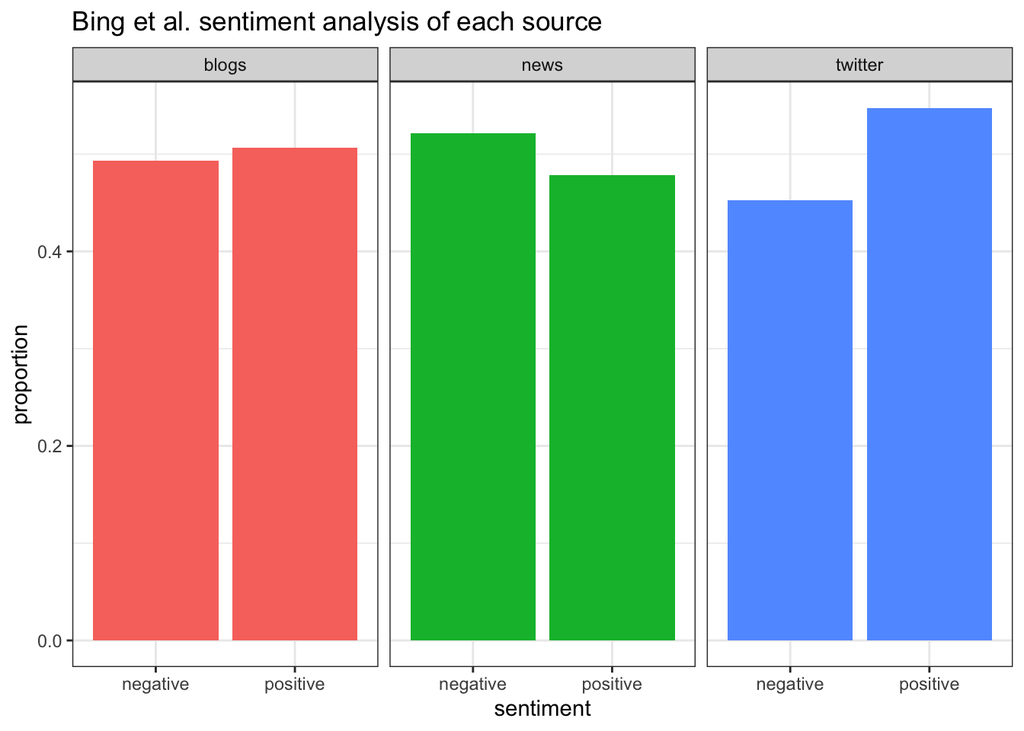

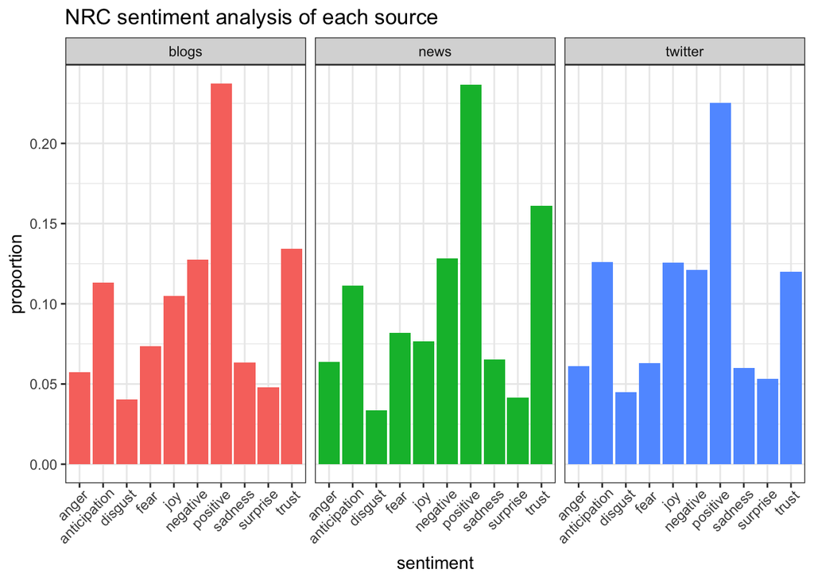

```r
# AFINN
df_eng_afinn <- df_eng %>% inner_join(df_afinn, by = "word")
df_eng_afinn_count <- df_eng_afinn %>% count(value, source, sort = TRUE)
df_eng_afinn_count <- df_eng_afinn_count %>%
       group_by(source) %>%
       mutate(proportion = n/sum(n))

df_eng_afinn_count %>%

       ggplot(aes(x = as.factor(value), y = proportion, fill = source)) +
       geom_col() +
       facet_wrap(~source) +

       theme_bw() +
       xlab("value") +
       ggtitle("AFINN sentiment analysis of each source") +
       theme(legend.position = "none")

# Bing
df_eng_bing <- df_eng %>% inner_join(df_bing, by = "word")
df_eng_bing_count <- df_eng_bing %>% count(sentiment, source, sort = TRUE)
df_eng_bing_count <- df_eng_bing_count %>%
       group_by(source) %>%
       mutate(proportion = n/sum(n))

df_eng_bing_count %>%

       ggplot(aes(x = sentiment, y = proportion, fill = source)) +
       geom_col() +
       facet_wrap(~source) +

       theme_bw() +
       ggtitle("Bing et al. sentiment analysis of each source") +
       theme(legend.position = "none")

# NRC
df_eng_nrc <- df_eng %>% inner_join(df_nrc, by = "word")
df_eng_nrc_count <- df_eng_nrc %>% count(sentiment, source, sort = TRUE)
df_eng_nrc_count <- df_eng_nrc_count %>%
       group_by(source) %>%
       mutate(proportion = n/sum(n))

df_eng_nrc_count %>%

       ggplot(aes(x = sentiment, y = proportion, fill = source)) +
       geom_col() +
       facet_wrap(~source) +

       theme_bw() +
       ggtitle("NRC sentiment analysis of each source") +
       theme(legend.position = "none",
             axis.text.x = element_text(angle = 45, hjust = 0.9))
```

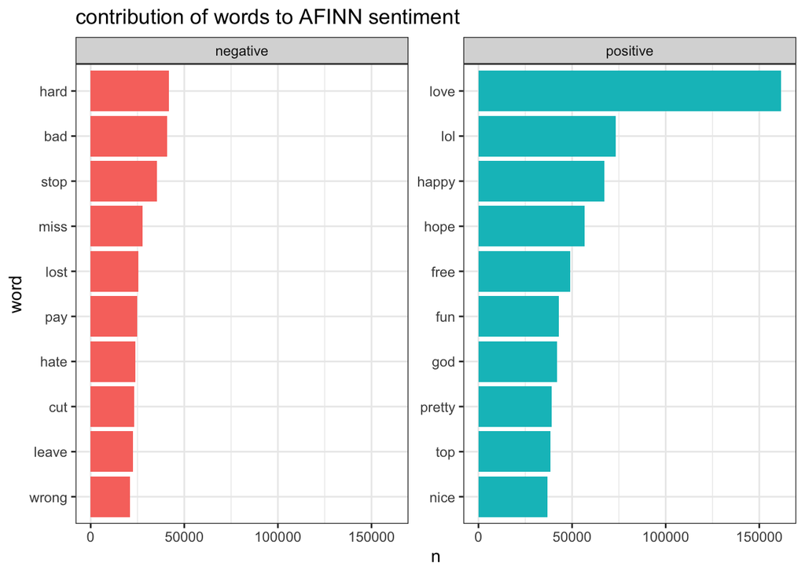

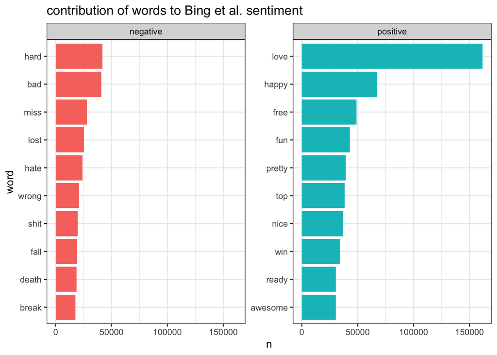

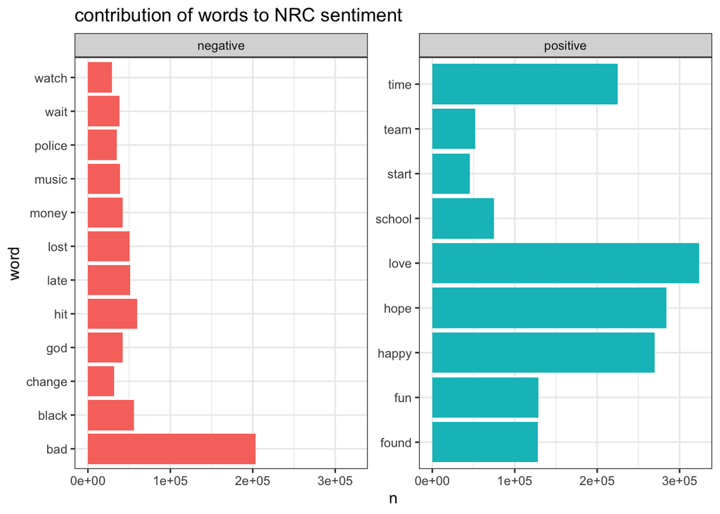

```r
# AFINN
df_eng_afinn_wordcounts <- df_eng_afinn %>%
       count(word, value, sort = TRUE) %>%
       mutate(sentiment = ifelse(value > 0, "positive", "negative"))

df_eng_afinn_wordcounts %>%
       group_by(sentiment) %>%
       slice_max(order_by = n, n = 10) %>%
       ungroup() %>%
       mutate(word = reorder(word, n)) %>%

       ggplot(aes(x = n, y = word, fill = sentiment)) +
       geom_col(show.legend = FALSE) +
       facet_wrap(~sentiment, scales = "free_y") +
       theme_bw() +
       ggtitle("contribution of words to AFINN sentiment")

# Bing
df_eng_bing_wordcounts <- df_eng_bing %>% count(word, sentiment, sort = TRUE)

df_eng_bing_wordcounts %>%
       group_by(sentiment) %>%
       slice_max(order_by = n, n = 10) %>%
       ungroup() %>%
       mutate(word = reorder(word, n)) %>%

       ggplot(aes(x = n, y = word, fill = sentiment)) +
       geom_col(show.legend = FALSE) +
       facet_wrap(~sentiment, scales = "free_y") +
       theme_bw() +
       ggtitle("contribution of words to Bing et al. sentiment")

# NRC
df_eng_nrc_wordcounts <- df_eng_nrc %>%
       count(word, sentiment, sort = TRUE) %>%
       mutate(pos_neg = case_when(

              sentiment %in% c("positive", "trust", "joy", "surprise", "anticipation") ~ "positive",
              sentiment %in% c("anger", "disgust", "fear", "negative", "sadness") ~ "negative"

       ))

df_eng_nrc_wordcounts %>%
       group_by(pos_neg) %>%
       slice_max(order_by = n, n = 20) %>%
       ungroup() %>%

       ggplot(aes(x = n, y = word, fill = pos_neg)) +
       geom_col(show.legend = FALSE) +
       facet_wrap(~pos_neg, scales = "free_y") +
       theme_bw() +
       ggtitle("contribution of words to NRC sentiment")
```

### Bigrams

Sample 10% of data from each source because full files are too big for this analysis

```r
# sample from each
df_eng_news_spl <- sample_n(df_eng_news, size = nrow(df_eng_news)*0.1)
df_eng_blogs_spl <- sample_n(df_eng_blogs, size = nrow(df_eng_blogs)*0.1)
df_eng_twitter_spl <- sample_n(df_eng_twitter, size = nrow(df_eng_twitter)*0.1)

# combine into one
df_eng_spl <- bind_rows(df_eng_news_spl, df_eng_blogs_spl, df_eng_twitter_spl)
```

```r
# unnest to 2-gram
df_eng_bigram <- df_eng_spl %>% unnest_tokens(bigram, text, token = "ngrams", n = 2)

# remove lines with numbers
df_eng_bigram <- df_eng_bigram %>% filter(!grepl("[0-9]", bigram))

# remove stop words
df_eng_bigrams_sep <- df_eng_bigram %>% separate(bigram, c("word1", "word2"), sep = " ")
df_eng_bigrams_filt <- df_eng_bigrams_sep %>%
       filter(!word1 %in% stop_words$word) %>%
       filter(!word2 %in% stop_words$word) %>%
       filter(!is.na(word1), !is.na(word2))

# count
df_eng_bigrams_count <- df_eng_bigrams_filt %>% count(word1, word2, sort = TRUE)

# unite
df_eng_bigrams_count <- df_eng_bigrams_count %>% unite(bigram, word1, word2, sep = " ")
```

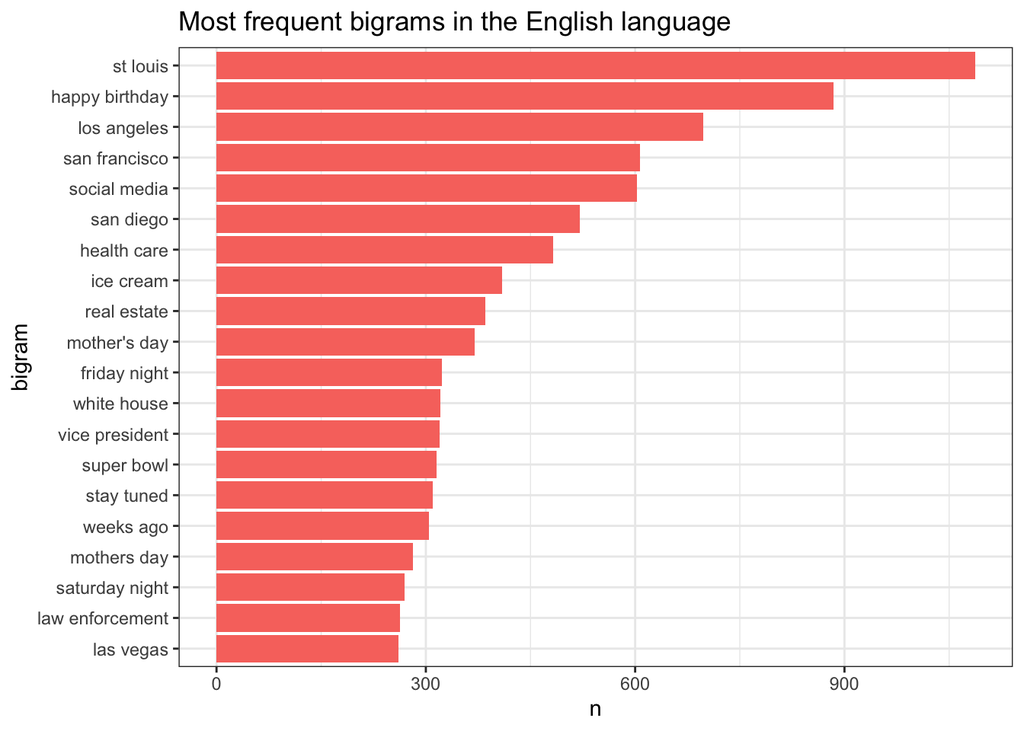

```r
# plot frequencies
df_eng_bigrams_count %>% head(n = 20) %>% mutate(bigram = reorder(bigram, n)) %>%

               ggplot(aes(x = n, y = bigram)) +
               geom_col(fill = "#F8766D") +
               theme_bw() +
               ggtitle("Most frequent bigrams in the English language")
```

Visualize network of bigrams

```r
igraph_eng_bigrams <- df_eng_bigrams_filt %>%
       filter(!is.na(word1), !is.na(word2)) %>%
       count(word1, word2, sort = TRUE) %>%
       filter(n > 200) %>%
       graph_from_data_frame()
```

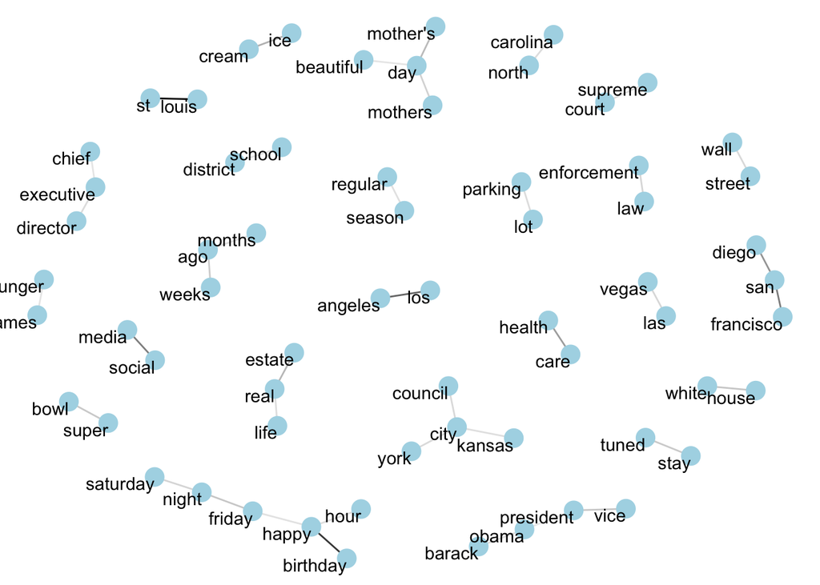

```r
set.seed(2021)

ggraph(igraph_eng_bigrams, layout = "fr") +
       geom_edge_link(aes(edge_alpha = n), show.legend = FALSE, end_cap = circle(.07, "inches")) +
       geom_node_point(color = "lightblue", size = 5) +
       geom_node_text(aes(label = name), vjust = 1, hjust = 1) +
       theme_void()
```

### Trigrams

```r
# unnest to 3-gram
df_eng_trigram <- df_eng_spl %>% unnest_tokens(trigram, text, token = "ngrams", n = 3)

# remove lines with numbers
df_eng_trigram <- df_eng_trigram %>% filter(!grepl("[0-9]", trigram))

# remove stop words
df_eng_trigrams_sep <- df_eng_trigram %>% separate(trigram, c("word1", "word2", "word3"), sep = " ")
df_eng_trigrams_filt <- df_eng_trigrams_sep %>%
       filter(!word1 %in% stop_words$word) %>%
       filter(!word2 %in% stop_words$word) %>%
       filter(!word3 %in% stop_words$word) %>%
       filter(!is.na(word1), !is.na(word2), !is.na(word3))

# count
df_eng_trigrams_count <- df_eng_trigrams_filt %>% count(word1, word2, word3, sort = TRUE)

# unite
df_eng_trigrams_count <- df_eng_trigrams_count %>% unite(trigram, word1, word2, word3, sep = " ")
```

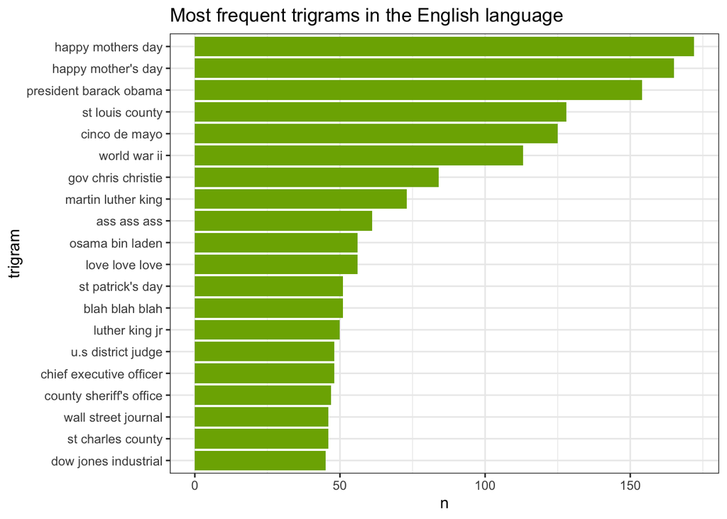

```r
df_eng_trigrams_count %>% head(n = 20) %>% mutate(trigram = reorder(trigram, n)) %>%

       ggplot(aes(x = n, y = trigram)) +
       geom_col(fill = "#7CAE00") +
       theme_bw() +
       ggtitle("Most frequent trigrams in the English language")
```

### Unique words

Calculate the number of unique words in a frequency sorted dictionary needed to cover 50% and 90% of all word instances in the language.

```r
# include stop words this time
df_eng_all <- rbind(df_eng_news_unnest, df_eng_blogs_unnest, df_eng_twitter_unnest)

# frequency of all words including stop words
df_eng_wordcount_all <- df_eng_all %>% count(word, sort = TRUE)

# loop through to calculate
n_total.words<- sum(df_eng_wordcount_all$n)
half <- 0.5*n_total.words
most <- 0.9*n_total.words

c <- 0
i <- 1

while(c < half){
       c <- c + df_eng_wordcount_all[i,]$n;
       i <- i+1;
}

n_half <- i

while(c < most){
       c <- c + df_eng_wordcount_all[i,]$n;
       i <- i+1;
}

n_90 <- i
```

```r
n_half
```

```
## [1] 145
```

```r
n_90
```

```
## [1] 7414
```